# Lista 1

Guilherme Schneider Markus(00330054) e Lisiane Bueno Peitz (00172039)

2023-06-11

**Exercício 1)** Seja Y uma v.a. com distribuição logarítmica, com probabilidade de expressa por

f(y; ρ) = −ρ^y{y log(1 − ρ)}^−1,

em que y = 1, 2, … e 0 < ρ < 1.

1. Mostre que essa distribuição pertence à família exponencial;
2. Identifique θ, ϕ, b(θ) e c(y; ϕ);
3. Calcule µ e V (µ);
4. Determine a esperança de Y;
5. Obtenha a função desvio supondo uma amostra de n variáveis aleatórias independentes de parâmetros ρi.

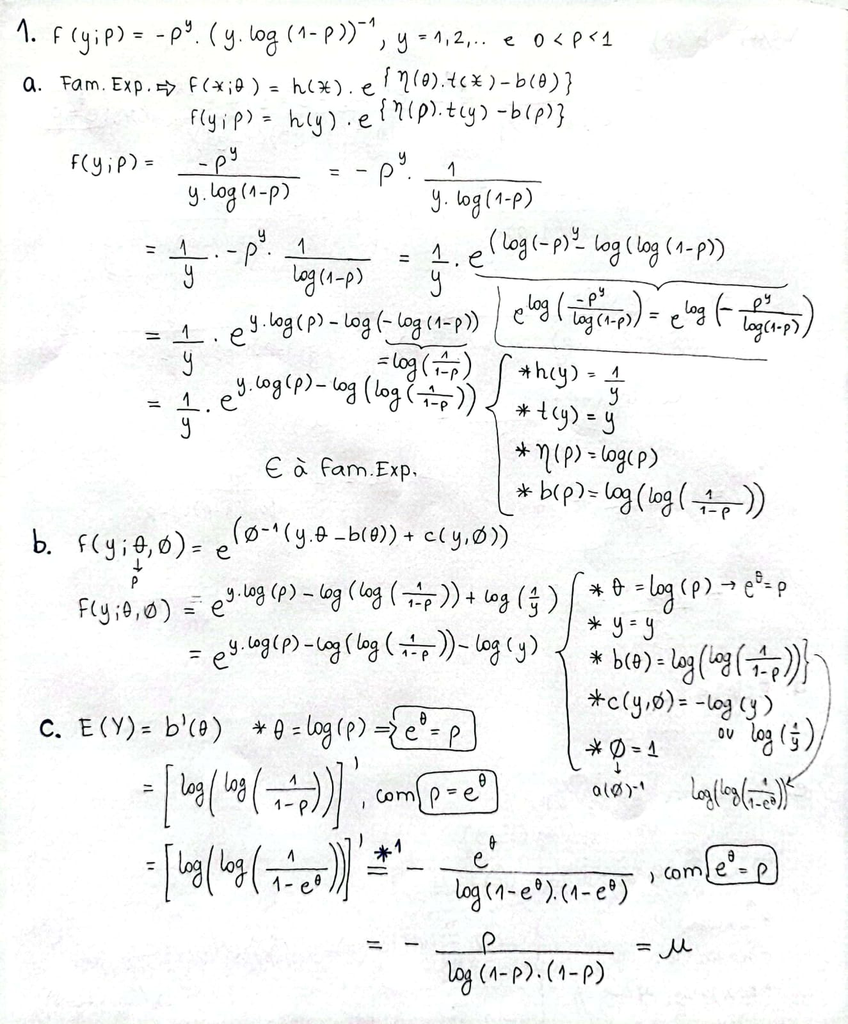

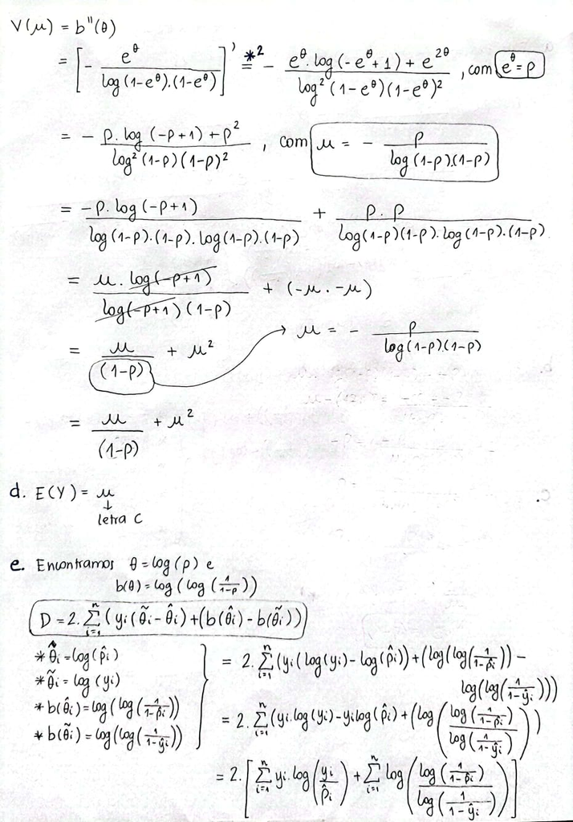

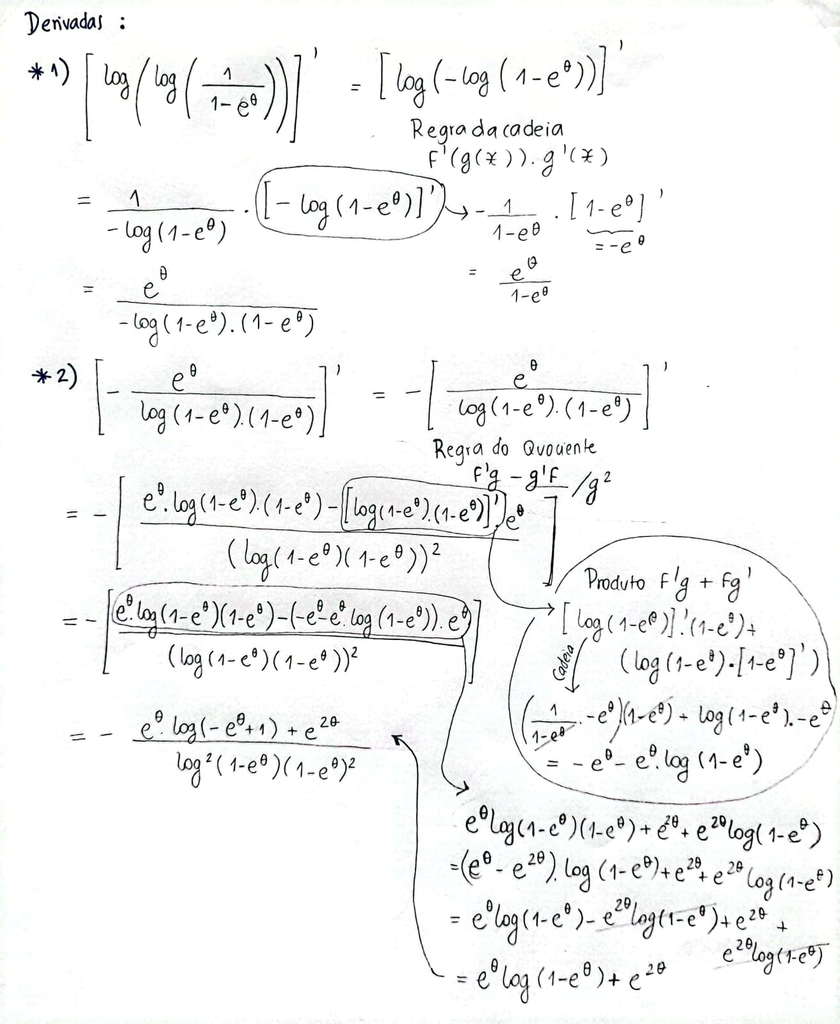

**Exercício 2)** Mostre que a distribuição Geométrica, com função de probabilidade:

f(y; π) = π(1 − π)^2,

y = 0, 1, 2, …; 0 < π < 1

pertence à família exponencial e represente-a na forma canônica. Identifique θ, ϕ, b(θ) e c(y; ϕ). Usando aspropriedades dessa família, determine E(Y), var(Y) e V(µ).

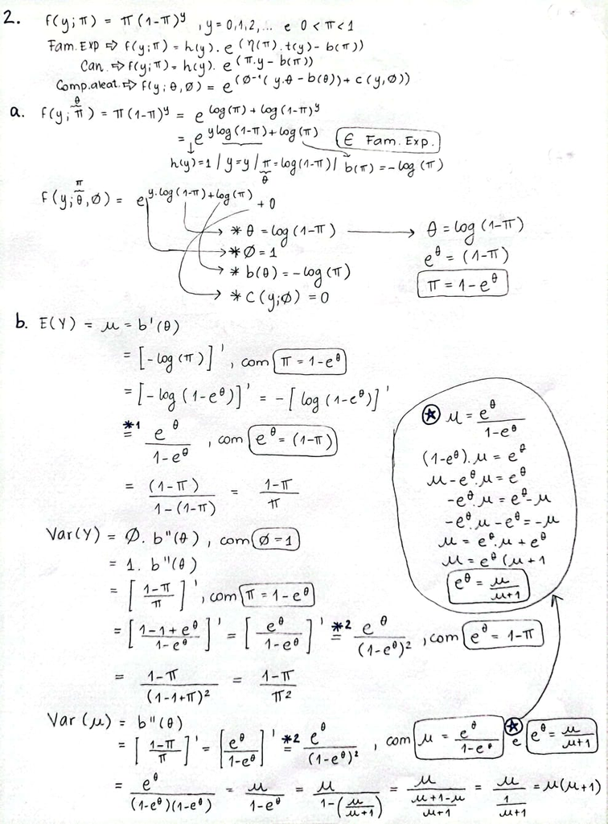

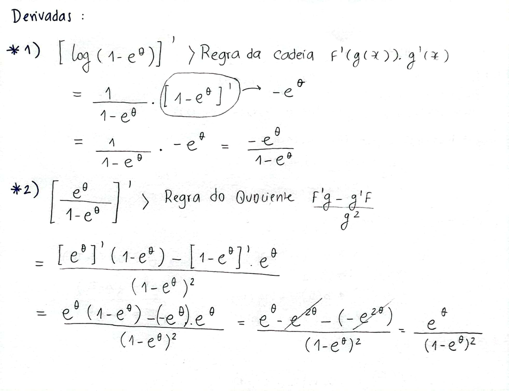

**Exercício 3)** Sejam Y1, Y2, …, Yn variáveis aleatórias independentes com Yi|xi ∼ N(µi, σ2) e µi = β0 + log(β1 + β2xi), para i = 1, 2, …, n. Isso configura um Modelo Linear Generalizado? Justifique sua resposta.

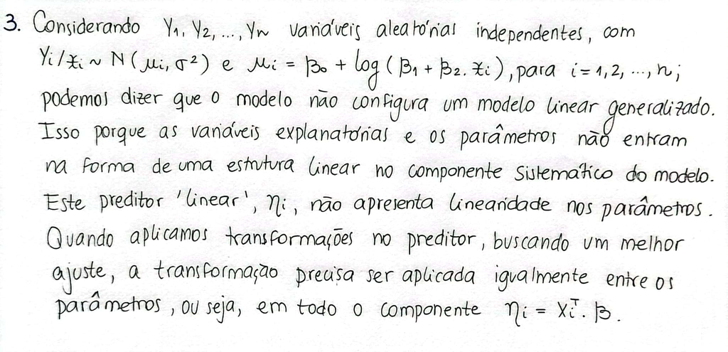

**Exercício 4)** Os itens a-d descrevem os objetivos de diferentes estudos. O objetivo do exercício é propor modelos lineares generalizados apropriados em cada situação. Para isso, você deve atender aos seguintes itens:

I. Identificar a variável resposta, o conjunto de valores que ela pode assumir e a possível forma de sua distribuição;

2. Identificar as variáveis explicativas e suas respectivas escalas;
3. Postular uma distribuição de probabilidades apropriada, de acordo com as propriedades da variável resposta;
4. Sugerir o preditor linear a ser considerado;

V. Propor uma função de ligação pertinente à distribuição de probabilidades escolhida;

6. Escrever o MLG resultante em duas etapas, conforme visto em aula, especificando, num primeiro momento, a distribuição da resposta condicional às covariáveis e, posteriormente, a relação entre a média da resposta e o preditor linear.
1. Investigar o efeito da idade, sexo, altura, consumo médio diário de calorias e gasto médio diário de energia na perda de peso de pacientes obesos;

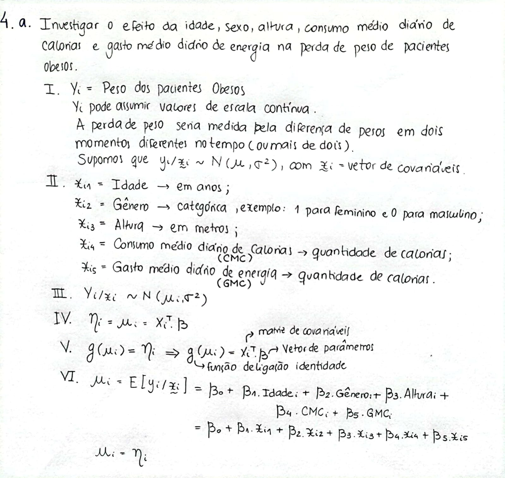

2. Avaliar a mortalidade de cobaias infectadas após exposição a uma bactéria quando cinco diferentes níveis de exposição são considerados e 50 ratos expostos a cada nível, sendo contado o número de ratos mortos após um tempo fixado de exposição;

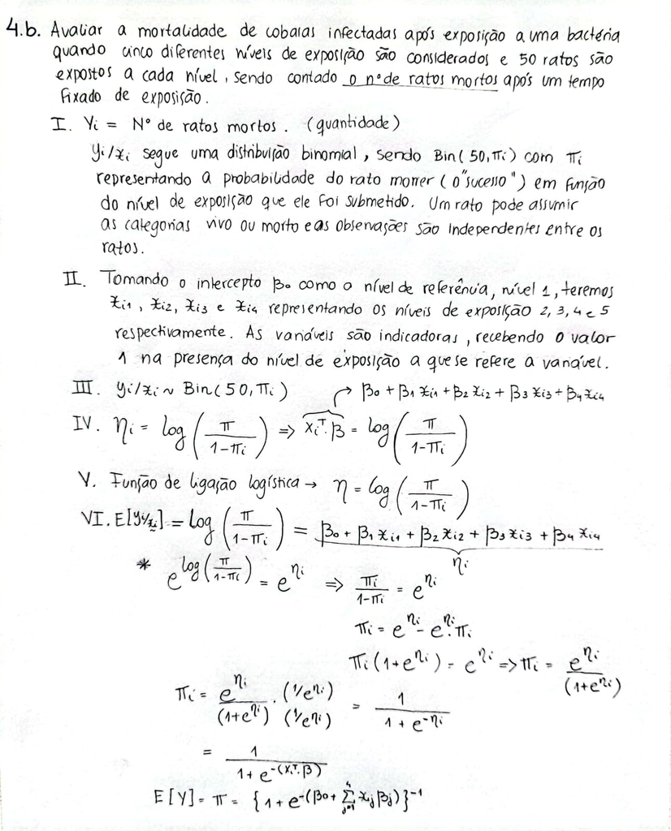

3. A relação entre o número de visitas semanais de clientes a um supermercado e o número de pessoas na família, a renda familiar e a distância ao supermercado;

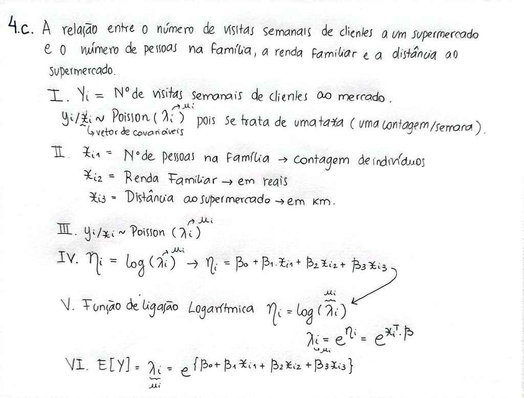

4. Avaliar a relação entre o tempo de sobrevida de pacientes com determinado tipo de câncer segundo o sexo e tipo de tratamento (T1, T2 e T3). Nota: Desconfia-se que os tratamentos proporcionem resultados diferentes de acordo com o sexo, e que a distribuição dos tempos de sobrevida seja assimétrica.

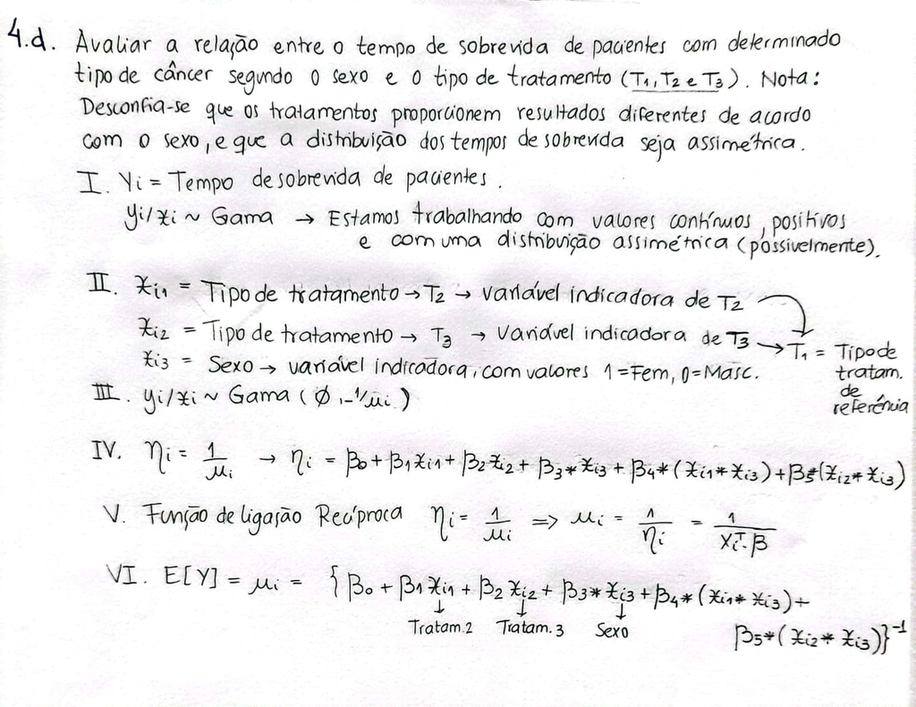

**Exercício 5)** Seja Y pertencente à família exponencial de distribuições, então a função densidade ou função de probabilidade de Y pode ser expressa na forma

f(y; θ, ϕ) = exp{[yθ − b(θ)]/a(ϕ) + c(y; ϕ)},

em que b(.) e c(.; .) são funções diferenciáveis. Suponha ϕ conhecido seja l(θ) = log f(y; θ, ϕ) o logaritmo da função de verossimilhança. Se l(θ) é pelo menos duas vezes diferenciável em θ mostre que

1. E(∂l(θ)/∂θ) = 0
2. E(∂2l(θ)/∂θ2)= −E([∂l(θ)/∂θ]^2)

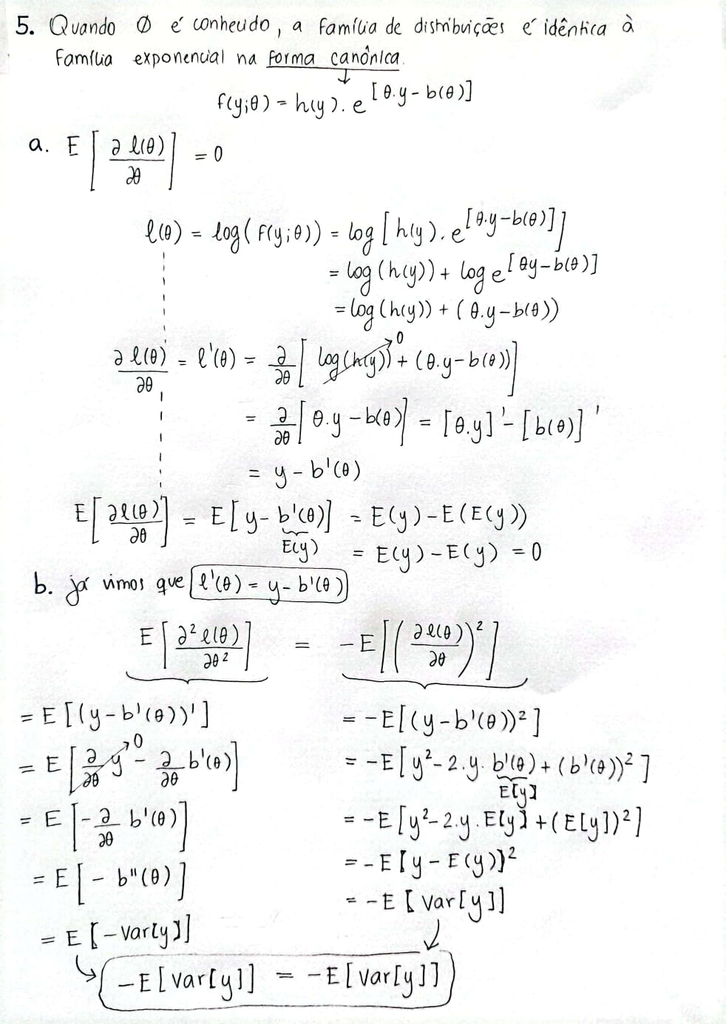

**Exercício 7)** Considere a distribuição Estável cuja densidade é dada por

f(y; θ, ϕ) = a(y, ϕ) exp {ϕ [θ(y + 1) − θ log(θ)]},

em que θ > 0, −∞ < y < ∞, ϕ

−1 > 0 é o parâmetro de dispersão e a(., .) é uma função normalizadora.

1. Mostre que essa distribuição pertence à família exponencial;
2. Encontre a função de variância;
3. Obtenha a função desvio supondo uma amostra de n variáveis aleatórias independentes de médias µi e parâmetro de dispersão ϕ^1.

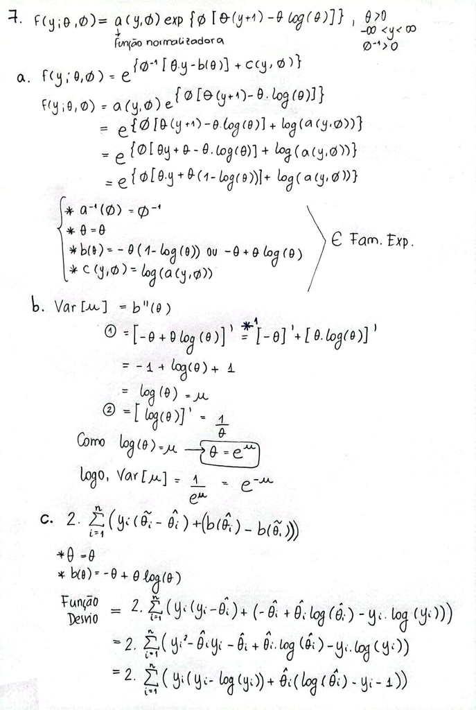

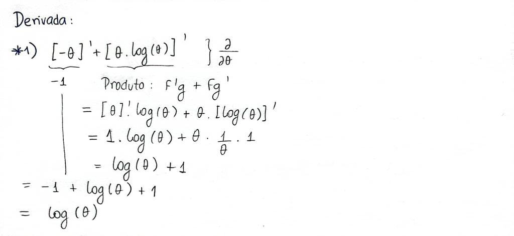

**Exercício 8)** Seja Y uma v.a. com distribuição de Poisson truncada, com parâmetro λ > 0, isto é, com função de probabilidade expressa por

f(y; λ) = e^−λ λ^y / y!(1 − e−λ) = λ^y / y!(eλ − 1), y = 1, 2, …

Mostre que: a) essa distribuição é um membro da família exponencial na forma canônica;

2. E(Y) = µ = λ / 1 − e−λ;
3. Var(Y) = λ1 − e−λ(1 − λe^−λ / 1 − e−λ)= µ(1 + λ − µ).

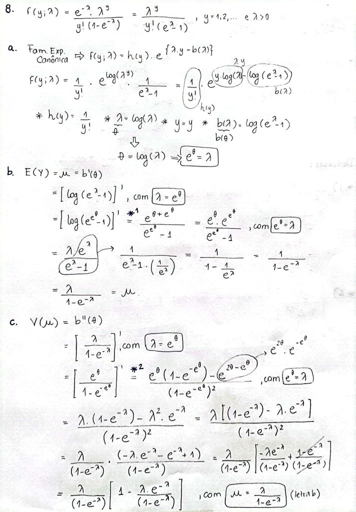

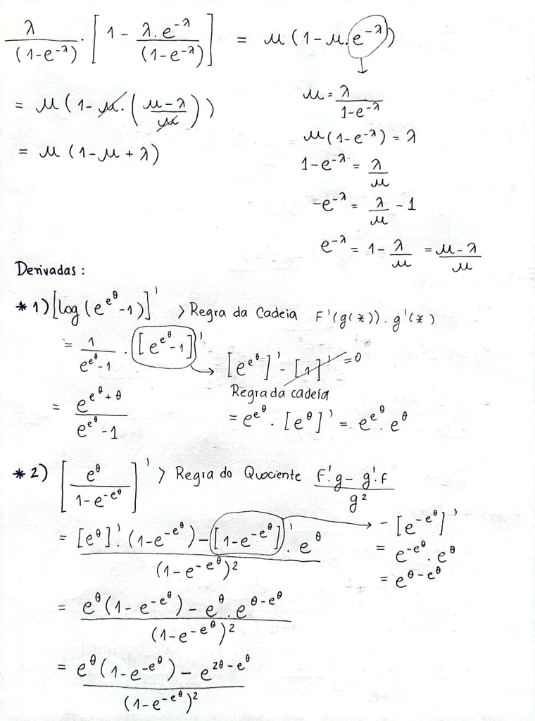

**Exercício 9)** A base de dados Supermercados.csv, disponível no moodle da disciplina, apresenta os gastos de 100 clientes de um pequeno supermercado em suas últimas compras e algumas variáveis adicionais, conforme descrito na sequência:

**Forma de pagamento:** Dinheiro, Cartão de Crédito ou Vale-Alimentação;

**Tipo de cliente:** Cliente cadastrado ou Cliente Não Cadastrado;

**Distância:** Distância da residência do cliente ao supermercado;

**Npessoas:** Número de pessoas que moram com o cliente (incluindo o próprio cliente); Gasto: Gasto do cliente em sua última compra (em centenas de reais).

Deseja-se ajustar um modelo para o gasto dos clientes com base nas demais variáveis. Esse exercício tem várias etapas. Utilizando estes dados, e a função glm do R:

**Análise descritiva**

1. Medidas descritivas referentes aos gastos (média, mediana, desvio padrão, variância, coeficiente de variação) e às demais variáveis;

**Distância**

| Media | Desvio | Variancia | Mediana | CV |
| --- | --- | --- | --- | --- |
| 5.09 | 2.75 | 7.59 | 4.95 | 54.15 |

**Npessoas**

| Media | Desvio | Variancia | Mediana | CV |
| --- | --- | --- | --- | --- |
| 3.37 | 2.14 | 4.6 | 3 | 63.64 |

**Gasto**

| Media | Desvio | Variancia | Mediana | CV |
| --- | --- | --- | --- | --- |
| 0.6 | 0.69 | 0.47 | 0.4 | 114.17 |

2. Box-plots de Gasto vs Tipo de Cliente e Gasto vs Forma de Pagamento;

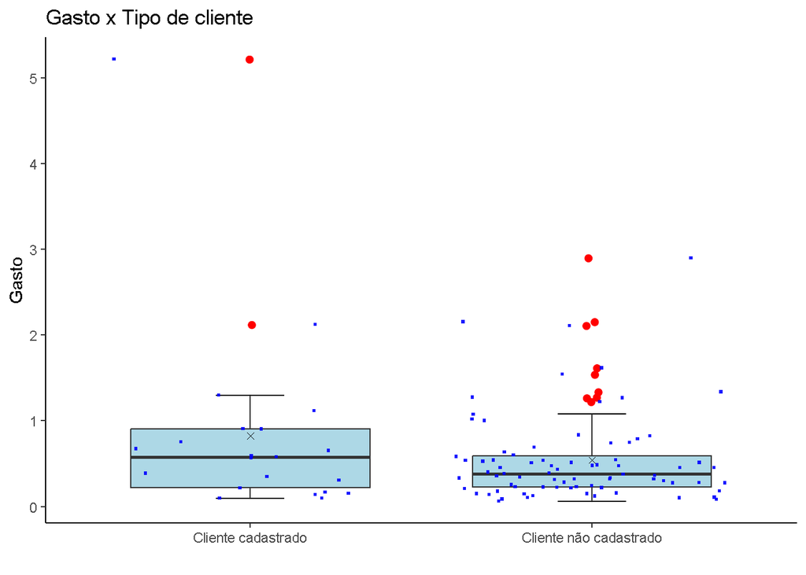

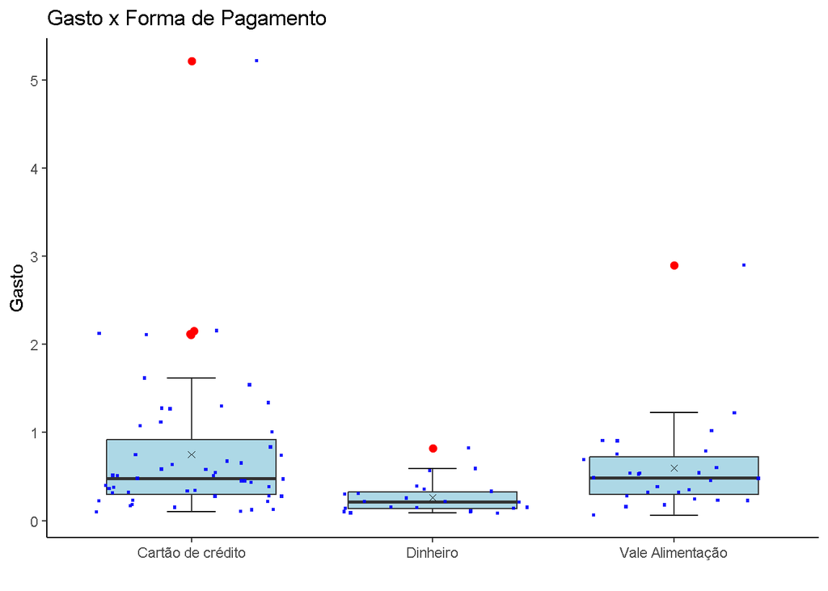

**Ajuste de um modelo linear**

3. Ajuste um modelo linear considerando o gasto como variável resposta e as demais variáveis como explicativas;

```r
modelo = lm(dados$Gasto ~ dados$`Forma de pagamento` + dados$`Tipo de cliente` + dados$Distancia + dados$Npessoas)
summary(modelo)
```

```
##
## Call:
## lm(formula = dados$Gasto ~ dados$`Forma de pagamento` + dados$`Tipo de cliente` +
##     dados$Distancia + dados$Npessoas)
##
## Residuals:
##     Min      1Q  Median      3Q     Max
## -0.8430 -0.2756 -0.1116  0.2167  3.4311
##
## Coefficients:
##                                               Estimate Std. Error t value
## (Intercept)                                    0.62651    0.19980   3.136
## dados$`Forma de pagamento`Dinheiro            -0.52113    0.15300  -3.406
## dados$`Forma de pagamento`Vale Alimentação    -0.17089    0.14232  -1.201
## dados$`Tipo de cliente`Cliente não cadastrado -0.31269    0.14758  -2.119
## dados$Distancia                               -0.01263    0.02193  -0.576
## dados$Npessoas                                 0.13271    0.02802   4.736
##                                               Pr(>|t|)
## (Intercept)                                   0.002289 **
## dados$`Forma de pagamento`Dinheiro            0.000971 ***
## dados$`Forma de pagamento`Vale Alimentação    0.232865
## dados$`Tipo de cliente`Cliente não cadastrado 0.036747 *
## dados$Distancia                               0.566186
## dados$Npessoas                                7.71e-06 ***
## ---
## Signif. codes:  0 '***' 0.001 '**' 0.01 '*' 0.05 '.' 0.1 ' ' 1
##
## Residual standard error: 0.5937 on 94 degrees of freedom
## Multiple R-squared:  0.2908, Adjusted R-squared:  0.253
## F-statistic: 7.707 on 5 and 94 DF,  p-value: 4.14e-06
```

4. Faça o diagnóstico do ajuste com base nos gráficos de resíduos;

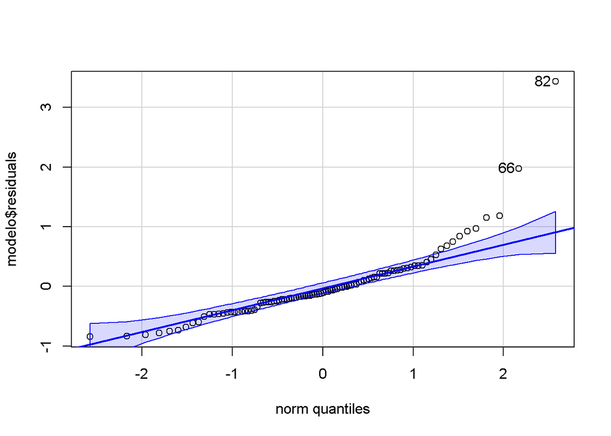

```
## [1] 82 66
```

Observando o gráfico dos residuos, não atente a normalidade, apresentando desvios em excesso na parte maior dos dados, com ressalva aos resíduos números 66 e 82.

**Ajuste de um modelo linear generalizado**

5. Ajuste um MLG com distribuição Gama e função de ligação inversa (canônica);

```r
attach(dados)

modelo_gama <- glm(Gasto ~ Npessoas + `Forma de pagamento` + `Tipo de cliente` + Distancia,
                family = Gamma(link = "inverse"))

detach(dados)

summary(modelo_gama)
```

```
##
## Call:
## glm(formula = Gasto ~ Npessoas + `Forma de pagamento` + `Tipo de cliente` +
##     Distancia, family = Gamma(link = "inverse"))
##
## Coefficients:
##                                          Estimate Std. Error t value Pr(>|t|)
## (Intercept)                              1.952685   0.371839   5.251 9.35e-07
## Npessoas                                -0.193889   0.038699  -5.010 2.54e-06
## `Forma de pagamento`Dinheiro             2.283944   0.629280   3.629 0.000462
## `Forma de pagamento`Vale Alimentação     0.306218   0.265616   1.153 0.251892
## `Tipo de cliente`Cliente não cadastrado  0.390237   0.235097   1.660 0.100267
## Distancia                               -0.003772   0.044248  -0.085 0.932245
##
## (Intercept)                             ***
## Npessoas                                ***
## `Forma de pagamento`Dinheiro            ***
## `Forma de pagamento`Vale Alimentação
## `Tipo de cliente`Cliente não cadastrado
## Distancia
## ---
## Signif. codes:  0 '***' 0.001 '**' 0.01 '*' 0.05 '.' 0.1 ' ' 1
##
## (Dispersion parameter for Gamma family taken to be 0.5727197)
##
##     Null deviance: 77.829  on 99  degrees of freedom
## Residual deviance: 46.599  on 94  degrees of freedom
## AIC: 49.72
##
## Number of Fisher Scoring iterations: 6
```

6. Ajuste um MLG com distribuição Normal Inversa;

```r
attach(dados)

normal_inversa <- glm(Gasto ~ Npessoas + `Forma de pagamento` + `Tipo de cliente` + Distancia,
                      family = inverse.gaussian(link = "1/mu^2")) # Função de ligação da inversa

detach(dados)

summary(normal_inversa)
```

```
##
## Call:
## glm(formula = Gasto ~ Npessoas + `Forma de pagamento` + `Tipo de cliente` +
##     Distancia, family = inverse.gaussian(link = "1/mu^2"))
##
## Coefficients:
##                                         Estimate Std. Error t value Pr(>|t|)
## (Intercept)                              4.14429    1.31084   3.162  0.00211 **
## Npessoas                                -0.43495    0.13383  -3.250  0.00160 **
## `Forma de pagamento`Dinheiro            11.79402    3.66826   3.215  0.00179 **
## `Forma de pagamento`Vale Alimentação     0.71140    1.01188   0.703  0.48376
## `Tipo de cliente`Cliente não cadastrado  0.57491    0.86623   0.664  0.50851
## Distancia                               -0.07708    0.16926  -0.455  0.64990
## ---
## Signif. codes:  0 '***' 0.001 '**' 0.01 '*' 0.05 '.' 0.1 ' ' 1
##
## (Dispersion parameter for inverse.gaussian family taken to be 1.30947)
##
##     Null deviance: 177.83  on 99  degrees of freedom
## Residual deviance: 128.48  on 94  degrees of freedom
## AIC: 53.719
##
## Number of Fisher Scoring iterations: 7
```

7. Qual modelo desempenhou um melhor ajuste Gama ou Normal Inversa? (Análise a função desvio e os gráficos de resíduos).

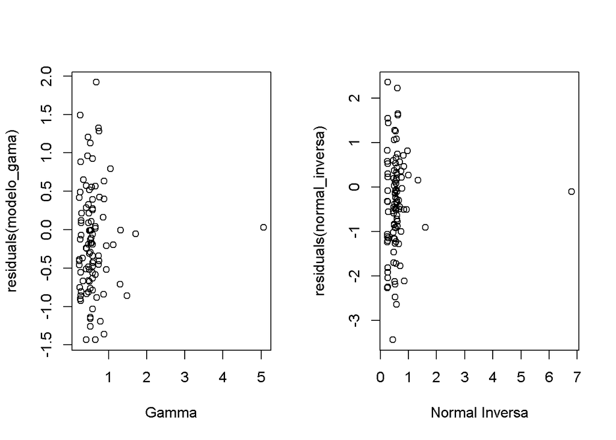

```r
par(mfrow=c(1,2))

plot(fitted(modelo_gama),residuals(modelo_gama), xlab = "Gamma")
plot(fitted(normal_inversa),residuals(normal_inversa), xlab = "Normal Inversa")
```

```r
deviance(modelo_gama)
```

```
## [1] 46.59868
```

```r
deviance(normal_inversa)
```

```
## [1] 128.4845
```

Analisando o gráfico e os desvios de cada modelo, vimos que a distribuição gama apresentou melhor ajuste.